# INVESTIGATE A DATA SET - PROJECT 2 - TITANIC DATA SET

Submittd by: Naga Ramesh Kamisetti

## Details about the data set:

The titanic data set is taken from the kaggle website. This data set is a sample taken from the complete passenger list. There is no information regarding how this sample data is taken. I used a question and answer format to explore the dataset. some of the information about the dataset in the website is:

VARIABLE DESCRIPTIONS: survival Survival (0 = No; 1 = Yes) pclass Passenger Class (1 = 1st; 2 = 2nd; 3 = 3rd) name Name sex Sex age Age sibsp Number of Siblings/Spouses Aboard parch Number of Parents/Children Aboard ticket Ticket Number fare Passenger Fare cabin Cabin embarked Port of Embarkation (C = Cherbourg; Q = Queenstown; S = Southampton)

SPECIAL NOTES: Pclass is a proxy for socio-economic status (SES) 1st ~ Upper; 2nd ~ Middle; 3rd ~ Lower

Age is in Years; Fractional if Age less than One (1) If the Age is Estimated, it is in the form xx.5

With respect to the family relation variables (i.e. sibsp and parch) some relations were ignored. The following are the definitions used for sibsp and parch.

Sibling: Brother, Sister, Stepbrother, or Stepsister of Passenger Aboard Titanic Spouse: Husband or Wife of Passenger Aboard Titanic (Mistresses and Fiances Ignored) Parent: Mother or Father of Passenger Aboard Titanic Child: Son, Daughter, Stepson, or Stepdaughter of Passenger Aboard Titanic

Other family relatives excluded from this study include cousins, nephews/nieces, aunts/uncles, and in-laws. Some children travelled only with a nanny, therefore parch=0 for them. As well, some travelled with very close friends or neighbors in a village, however, the definitions do not support such relations.

### To import the required libraries:

```python
import pandas as pd
import numpy as np
import matplotlib.pyplot as plt
import seaborn as sns
%matplotlib inline
```

Read in the data:

```python
dataset = pd.read_csv("titanic_data.csv")
```

Create a copy of the data set:

```python
dataset1 = dataset.copy()
```

What are the dimensions of the data set?

```python
dataset1.shape
```

```
(891, 12)
```

### Get complete details about the column names and type of data?

```python
dataset1.info()
```

```
<class 'pandas.core.frame.DataFrame'>
RangeIndex: 891 entries, 0 to 890
Data columns (total 12 columns):
PassengerId    891 non-null int64
Survived       891 non-null int64
Pclass         891 non-null int64
Name           891 non-null object
Sex            891 non-null object
Age            714 non-null float64
SibSp          891 non-null int64
Parch          891 non-null int64
Ticket         891 non-null object
Fare           891 non-null float64
Cabin          204 non-null object
Embarked       889 non-null object
dtypes: float64(2), int64(5), object(5)
memory usage: 83.6+ KB
```

#### Age, Cabin and Embarked columns have missing values.

```python
#see  few rows of the dataframe
dataset1.head()
```

|  | PassengerId | Survived | Pclass | Name | Sex | Age | SibSp | Parch | Ticket | Fare | Cabin | Embarked |
| --- | --- | --- | --- | --- | --- | --- | --- | --- | --- | --- | --- | --- |
| 0 | 1 | 0 | 3 | Braund, Mr. Owen Harris | male | 22.0 | 1 | 0 | A/5 21171 | 7.2500 | NaN | S |
| 1 | 2 | 1 | 1 | Cumings, Mrs. John Bradley (Florence Briggs Th... | female | 38.0 | 1 | 0 | PC 17599 | 71.2833 | C85 | C |
| 2 | 3 | 1 | 3 | Heikkinen, Miss. Laina | female | 26.0 | 0 | 0 | STON/O2. 3101282 | 7.9250 | NaN | S |
| 3 | 4 | 1 | 1 | Futrelle, Mrs. Jacques Heath (Lily May Peel) | female | 35.0 | 1 | 0 | 113803 | 53.1000 | C123 | S |
| 4 | 5 | 0 | 3 | Allen, Mr. William Henry | male | 35.0 | 0 | 0 | 373450 | 8.0500 | NaN | S |

```python
dataset1.tail()
```

|  | PassengerId | Survived | Pclass | Name | Sex | Age | SibSp | Parch | Ticket | Fare | Cabin | Embarked |
| --- | --- | --- | --- | --- | --- | --- | --- | --- | --- | --- | --- | --- |
| 886 | 887 | 0 | 2 | Montvila, Rev. Juozas | male | 27.0 | 0 | 0 | 211536 | 13.00 | NaN | S |
| 887 | 888 | 1 | 1 | Graham, Miss. Margaret Edith | female | 19.0 | 0 | 0 | 112053 | 30.00 | B42 | S |
| 888 | 889 | 0 | 3 | Johnston, Miss. Catherine Helen "Carrie" | female | NaN | 1 | 2 | W./C. 6607 | 23.45 | NaN | S |
| 889 | 890 | 1 | 1 | Behr, Mr. Karl Howell | male | 26.0 | 0 | 0 | 111369 | 30.00 | C148 | C |
| 890 | 891 | 0 | 3 | Dooley, Mr. Patrick | male | 32.0 | 0 | 0 | 370376 | 7.75 | NaN | Q |

```python
dataset1[10:17]
```

|  | PassengerId | Survived | Pclass | Name | Sex | Age | SibSp | Parch | Ticket | Fare | Cabin | Embarked |
| --- | --- | --- | --- | --- | --- | --- | --- | --- | --- | --- | --- | --- |
| 10 | 11 | 1 | 3 | Sandstrom, Miss. Marguerite Rut | female | 4.0 | 1 | 1 | PP 9549 | 16.7000 | G6 | S |
| 11 | 12 | 1 | 1 | Bonnell, Miss. Elizabeth | female | 58.0 | 0 | 0 | 113783 | 26.5500 | C103 | S |
| 12 | 13 | 0 | 3 | Saundercock, Mr. William Henry | male | 20.0 | 0 | 0 | A/5. 2151 | 8.0500 | NaN | S |
| 13 | 14 | 0 | 3 | Andersson, Mr. Anders Johan | male | 39.0 | 1 | 5 | 347082 | 31.2750 | NaN | S |
| 14 | 15 | 0 | 3 | Vestrom, Miss. Hulda Amanda Adolfina | female | 14.0 | 0 | 0 | 350406 | 7.8542 | NaN | S |
| 15 | 16 | 1 | 2 | Hewlett, Mrs. (Mary D Kingcome) | female | 55.0 | 0 | 0 | 248706 | 16.0000 | NaN | S |
| 16 | 17 | 0 | 3 | Rice, Master. Eugene | male | 2.0 | 4 | 1 | 382652 | 29.1250 | NaN | Q |

### Find out the number of missing values in each of the columns?

```python
def missing_values(x):
   return sum(x.isnull())
print "Number of missing values in each column are: \n",dataset1.apply(missing_values,axis =0)
```

```
Number of missing values in each column are:
PassengerId      0
Survived         0
Pclass           0
Name             0
Sex              0
Age            177
SibSp            0
Parch            0
Ticket           0
Fare             0
Cabin          687
Embarked         2
dtype: int64
```

### Unique categories of the Pclass?

```python
dataset1.Pclass.unique()
```

```
array([3, 1, 2], dtype=int64)
```

### Unique categories of the Embarked column?

```python
dataset1.Embarked.unique()
```

```
array(['S', 'C', 'Q', nan], dtype=object)
```

'nan' represents not a number.

#### 'Age' has numerical values and some fraction and missing values. I want to conver them in to certain categories based on age of each passenger. So, I create a new column "Age_category" next to the age column in the dataset

```python
dataset1.insert(6,"Age_category",dataset1['Age'])
```

```python
def cutdf(x):
    return pd.cut(x,[0,10,20,30,60,dataset1['Age'].max()],right = True,labels =['kids','teen','young','adult','seniors'])

dataset1["Age_category"] = dataset1[["Age"]].apply(cutdf)
```

#### Look in to the data set after inserting the new column.

```python
dataset1.head()
```

|  | PassengerId | Survived | Pclass | Name | Sex | Age | Age_category | SibSp | Parch | Ticket | Fare | Cabin | Embarked |
| --- | --- | --- | --- | --- | --- | --- | --- | --- | --- | --- | --- | --- | --- |
| 0 | 1 | 0 | 3 | Braund, Mr. Owen Harris | male | 22.0 | young | 1 | 0 | A/5 21171 | 7.2500 | NaN | S |
| 1 | 2 | 1 | 1 | Cumings, Mrs. John Bradley (Florence Briggs Th... | female | 38.0 | adult | 1 | 0 | PC 17599 | 71.2833 | C85 | C |
| 2 | 3 | 1 | 3 | Heikkinen, Miss. Laina | female | 26.0 | young | 0 | 0 | STON/O2. 3101282 | 7.9250 | NaN | S |
| 3 | 4 | 1 | 1 | Futrelle, Mrs. Jacques Heath (Lily May Peel) | female | 35.0 | adult | 1 | 0 | 113803 | 53.1000 | C123 | S |
| 4 | 5 | 0 | 3 | Allen, Mr. William Henry | male | 35.0 | adult | 0 | 0 | 373450 | 8.0500 | NaN | S |

### How many people survived overall in the sample?

```python
no_of_survivers =float(sum(dataset1['Survived']))
print no_of_survivers
```

```
342.0
```

### What is the overall survival rate? ( Survival rate is the percentage of people who survived)

```python
print "Overall Survival rate is  equal to ",float(no_of_survivers/len(dataset1))*100,"%"
```

```
Overall Survival rate is  equal to  38.3838383838 %
```

## How many male and female passengers are in the sample?

```python
dataset1['Sex'].value_counts()
```

```
male      577
female    314
Name: Sex, dtype: int64
```

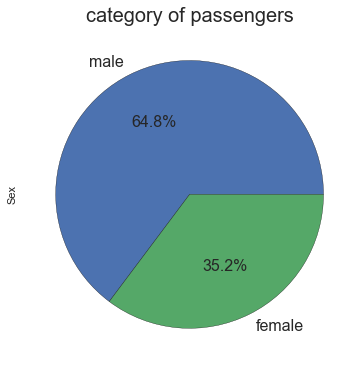

```python
#ax = plt.subplot(111)
#ax.xaxis.set_visible(True)

p = dataset1['Sex'].value_counts().plot(kind='pie',rot = 0,table = False,figsize = (6,6),fontsize=16,autopct='%1.1f%%')
p.set_title('category of passengers',fontsize=20);
```

## There are 64.8% male and 35.2% females in the sample.

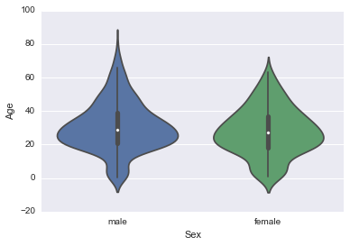

```python
sns.violinplot(x='Sex',y='Age',data=dataset1,split=True);
```

#### The above plot shows the variation of age's of male and female passengers. This excludes the rows having missing values.

## How many passengers are there in each Pclass?

```python
dataset1.Pclass.value_counts()
```

```
3    491
1    216
2    184
Name: Pclass, dtype: int64
```

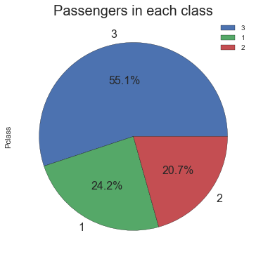

```python
p=dataset1.Pclass.value_counts().plot(kind='pie',rot=0,figsize=(6,6),autopct='%1.1f%%',fontsize=16,legend=True)
p.set_title("Passengers in each class",fontsize=20)
```

### There are 216 passengers(24.2%) in the 1st class, 184 passengers (20.7%) in the second class, and 491 passenegrs(55.1%) in the third class overall.

### How many passengers fall under each age category?

```python
dataset1.Age_category.value_counts()
```

```
adult      283
young      230
teen       115
kids        64
seniors     22
Name: Age_category, dtype: int64
```

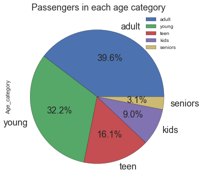

```python
p=dataset1.Age_category.value_counts().plot(kind='pie',rot=0,figsize=(6,6),autopct='%1.1f%%',fontsize=18,legend=True)
p.set_title(" Passengers in each age category",fontsize=18);
```

#### There are 283 adult(39.6%), 230 young(32.2%), 115 teen(16.1%), 64 kid(9%), 22 seniors(3.1%) in the sample.

```python
total_passengers_gby = dataset1.groupby(['Sex','Pclass'])
total_passengers_gby_unstacked = total_passengers_gby.size().unstack(0)
total_passengers_gby_unstacked
```

| Sex Pclass | female | male |
| --- | --- | --- |
| 1 | 94 | 122 |
| 2 | 76 | 108 |
| 3 | 144 | 347 |

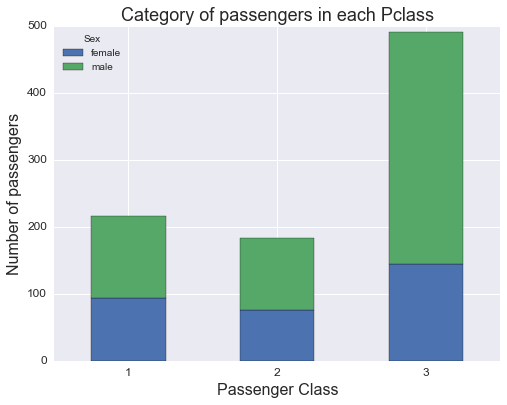

```python
p=total_passengers_gby_unstacked.plot(kind='bar',rot=0,figsize=(8,6),fontsize=12,stacked=True)
p.set_title("Category of passengers in each Pclass",fontsize=18)
p.set_ylabel("Number of passengers",fontsize=16)
p.set_xlabel("Passenger Class",fontsize=16);
```

#### The number of male passengers is more in each Passenger class. The number of male passengers in 3rd class is morethan double that of female passengers.

```python
total_passengers_withage_gby = dataset1.groupby(['Sex','Pclass','Age_category'])
total_passengers_withage_gby_unstacked = total_passengers_withage_gby.size().unstack(0)
total_passengers_withage_gby_unstacked
```

| Pclass | Sex Age_category | female | male |
| --- | --- | --- | --- |
| 1 | adult | 48.0 | 63.0 |
|  | kids | 1.0 | 2.0 |
|  | seniors | 2.0 | 12.0 |
|  | teen | 13.0 | 5.0 |
|  | young | 21.0 | 19.0 |
| 2 | adult | 30.0 | 44.0 |
|  | kids | 8.0 | 9.0 |
|  | seniors | NaN | 3.0 |
|  | teen | 8.0 | 10.0 |
|  | young | 28.0 | 33.0 |
| 3 | adult | 22.0 | 76.0 |
|  | kids | 22.0 | 22.0 |
|  | seniors | 1.0 | 4.0 |
|  | teen | 25.0 | 54.0 |
|  | young | 32.0 | 97.0 |

#### The above table shows the number of passengers in each age category separtated by gender.

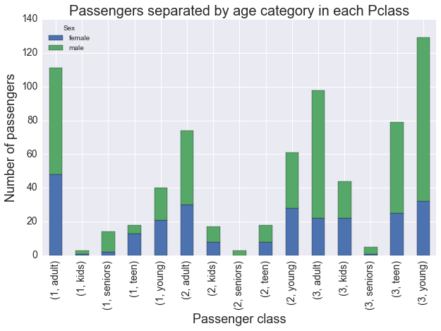

```python
p=total_passengers_withage_gby_unstacked.plot(kind='bar',figsize=(10,6),fontsize=14,stacked=True);
p.set_title("Passengers separated by age category in each Pclass",fontsize=20)
p.set_xlabel("Passenger class",fontsize=18)
p.set_ylabel("Number of passengers",fontsize=18);
```

#### For the purpose of exploring the data of survived passengers, I divided the data in to two subsets. One is Survived dataset named as "survivor" and the other one is "perished" for those passengers who died.

```python
survivor = dataset1[dataset1.Survived == 1]
survivor.head()
```

|  | PassengerId | Survived | Pclass | Name | Sex | Age | Age_category | SibSp | Parch | Ticket | Fare | Cabin | Embarked |
| --- | --- | --- | --- | --- | --- | --- | --- | --- | --- | --- | --- | --- | --- |
| 1 | 2 | 1 | 1 | Cumings, Mrs. John Bradley (Florence Briggs Th... | female | 38.0 | adult | 1 | 0 | PC 17599 | 71.2833 | C85 | C |
| 2 | 3 | 1 | 3 | Heikkinen, Miss. Laina | female | 26.0 | young | 0 | 0 | STON/O2. 3101282 | 7.9250 | NaN | S |
| 3 | 4 | 1 | 1 | Futrelle, Mrs. Jacques Heath (Lily May Peel) | female | 35.0 | adult | 1 | 0 | 113803 | 53.1000 | C123 | S |
| 8 | 9 | 1 | 3 | Johnson, Mrs. Oscar W (Elisabeth Vilhelmina Berg) | female | 27.0 | young | 0 | 2 | 347742 | 11.1333 | NaN | S |
| 9 | 10 | 1 | 2 | Nasser, Mrs. Nicholas (Adele Achem) | female | 14.0 | teen | 1 | 0 | 237736 | 30.0708 | NaN | C |

#### The above table represents the top 5 rows of the survivor data.

```python
perished=dataset1[dataset1.Survived==0]
```

### How many people survived?

```python
print len(survivor),' people survived'
```

```
342  people survived
```

### How many female and male passengers survived?

```python
survivor_gby_sex=survivor.groupby(['Sex'])
survivor_gby_sex.size()
```

```
Sex
female    233
male      109
dtype: int64
```

#### 233 female and 109 male passengers survived.

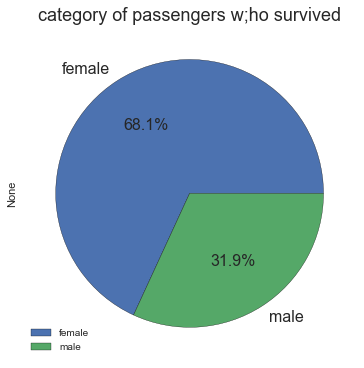

```python
survivor_gby_sex=survivor.groupby(['Sex'])
p=survivor_gby_sex.size().plot(kind='pie',rot=0,autopct='%1.1f%%',fontsize=16,figsize=(6,6),legend=True)
p.set_title("category of passengers w;ho survived",fontsize=18);
```

#### More female passengers survived than male passengers.

```python
perished_gby_sex=perished.groupby('Sex')
perished_gby_sex.size()
```

```
Sex
female     81
male      468
dtype: int64
```

```python
survivor_gby_sex_df=pd.DataFrame({'Survivor':survivor_gby_sex.size(),'Perished':perished_gby_sex.size()})
survivor_gby_sex_df
```

| Sex | Perished | Survivor |
| --- | --- | --- |
| female | 81 | 233 |
| male | 468 | 109 |

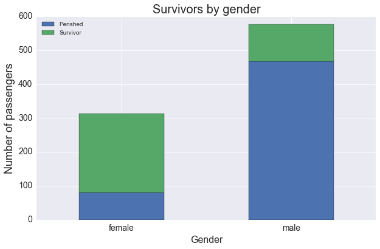

```python
p=survivor_gby_sex_df.plot(kind='bar',rot=0,fontsize=14,stacked=True,figsize=(10,6))
p.set_title('Survivors by gender',fontsize=20)
p.set_xlabel('Gender',fontsize=16)
p.set_ylabel('Number of passengers',fontsize=18);
```

### What is the percentage of female and male passengers who survived?

```python
survivor_gby_sex_df['Total_passengers']=dataset1.groupby('Sex').size()
survivor_gby_sex_df['survivor_proportion']=survivor_gby_sex_df['Survivor']/survivor_gby_sex_df['Total_passengers']
survivor_gby_sex_df
```

| Sex | Perished | Survivor | Total_passengers | survivor_proportion |
| --- | --- | --- | --- | --- |
| female | 81 | 233 | 314 | 0.742038 |
| male | 468 | 109 | 577 | 0.188908 |

74.2 % of the females and 18.9% of the males survived the crash. (in this sample)

### How many passengers in each Pclass survived?

```python
survivor_gby_pclass = survivor.groupby(['Pclass'])
perished_gby_pclass=perished.groupby('Pclass')
survivors_by_pclass_df = pd.DataFrame({'Survivors':survivor_gby_pclass.size(),'Perished':perished_gby_pclass.size()})
survivors_by_pclass_df
```

| Pclass | Perished | Survivors |
| --- | --- | --- |
| 1 | 80 | 136 |
| 2 | 97 | 87 |
| 3 | 372 | 119 |

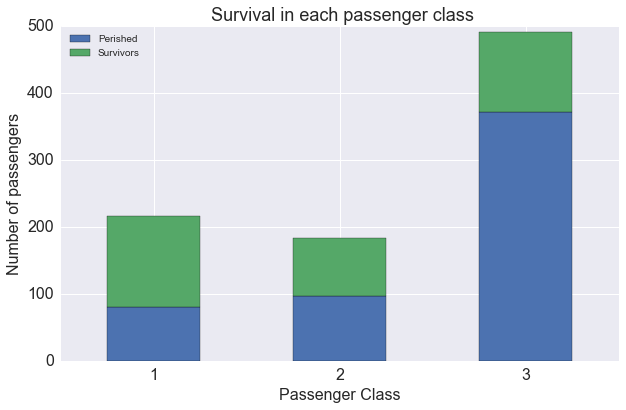

```python
p=survivors_by_pclass_df.plot(kind='bar',rot=0,figsize=(10,6),fontsize=16,stacked=True)
p.set_title(" Survival in each passenger class",fontsize=18)
p.set_ylabel("Number of passengers",fontsize=16)
p.set_xlabel("Passenger Class",fontsize=16);
```

#### Relatively, very less number of passenegrs in 3 class survived compared to 1 and 2nd class.

### What percent of people in each class survived?

```python
survivors_by_pclass_df['TotalPassengers']=dataset1.groupby('Pclass').size()
survivors_by_pclass_df['proportion']=(survivors_by_pclass_df['Survivors'])/(survivors_by_pclass_df['TotalPassengers'])
for i in range(3):
    print 'The percent of people in {} class who survived is: {} %'.format(i+1,survivors_by_pclass_df.proportion.ix[i+1]*100)
```

```
The percent of people in 1 class who survived is: 62.962962963 %
The percent of people in 2 class who survived is: 47.2826086957 %
The percent of people in 3 class who survived is: 24.2362525458 %
```

#### Passengers in 1 class survived more compared to passengers in 2 class and 3 class.

```python
survivor.Age_category.value_counts()
```

```
adult      119
young       84
teen        44
kids        38
seniors      5
Name: Age_category, dtype: int64
```

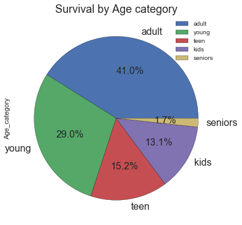

```python
p=survivor.Age_category.value_counts().plot(kind='pie',rot=0,figsize=(6,6),fontsize=16,autopct='%1.1f%%',legend=True)
p.set_title("Survival by Age category",fontsize=18);
```